[figure not shown]

*Copyright Pierian Data*

*For more information, visit us at www.pieriandata.com*

# Descriptive Statistics and Tests

In upcoming sections we'll talk about different forecasting models like ARMA, ARIMA, Seasonal ARIMA and others. Each model addresses a different type of time series. For this reason, in order to select an appropriate model we need to know something about the data.

In this section we'll learn how to determine if a time series is *stationary*, if it's *independent*, and if two series demonstrate *correlation* and/or *causality*.

- Goals
  - Be able to perform Augmented Dickey Fuller Test
  - Kwiatkowski-Phillips-Schmidt-Shin test for stationarity.
  - Calculate the BDS test statistic for independence of a time series
  - Return’s Ljung-Box Q Statistic
  - four tests for granger non-causality of 2 timeseries (maybe do this tests on two airline stocks against each other, or gas price versus airline stock/travel costs)

### Related Functions:

```
stattools.ccovf(x, y[, unbiased, demean])  crosscovariance for 1D

stattools.ccf(x, y[, unbiased])            cross-correlation function for 1d

stattools.periodogram(X)                   Returns the periodogram for the natural frequency of X


stattools.adfuller(x[, maxlag, regression, …])  Augmented Dickey-Fuller unit root test

stattools.kpss(x[, regression, lags, store])    Kwiatkowski-Phillips-Schmidt-Shin test for stationarity.

stattools.coint(y0, y1[, trend, method, …])     Test for no-cointegration of a univariate equation

stattools.bds(x[, max_dim, epsilon, distance])  Calculate the BDS test statistic for independence of a time series

stattools.q_stat(x, nobs[, type])               Returns Ljung-Box Q Statistic

stattools.grangercausalitytests(x, maxlag[, …]) Four tests for granger non-causality of 2 timeseries

stattools.levinson_durbin(s[, nlags, isacov])   Levinson-Durbin recursion for autoregressive processes


stattools.eval_measures.mse(x1, x2, axis=0)      mean squared error

stattools.eval_measures.rmse(x1, x2, axis=0)     root mean squared error

stattools.eval_measures.meanabs(x1, x2, axis=0)  mean absolute error
```

### For Further Reading:

**[Wikipedia:](https://en.wikipedia.org/wiki/Augmented_Dickey%E2%80%93Fuller_test)** Augmented Dickey–Fuller test  
**[Forecasting: Principles and Practice:](https://otexts.com/fpp2/accuracy.html)** Evaluating forecast accuracy

## Perform standard imports and load datasets

```python
import pandas as pd
import numpy as np
%matplotlib inline

# Ignore harmless warnings
import warnings
warnings.filterwarnings("ignore")

# Load a seasonal dataset
df1 = pd.read_csv('../Data/airline_passengers.csv',index_col='Month',parse_dates=True)
df1.index.freq = 'MS'

# Load a nonseasonal dataset
df2 = pd.read_csv('../Data/DailyTotalFemaleBirths.csv',index_col='Date',parse_dates=True)
df2.index.freq = 'D'

from statsmodels.tsa.stattools import ccovf,ccf,periodogram

from statsmodels.tsa.stattools import adfuller,kpss,coint,bds,q_stat,grangercausalitytests,levinson_durbin

from statsmodels.tools.eval_measures import mse, rmse, meanabs

# Alternative:
# from sklearn.metrics import mean_squared_error
```

# Tests for Stationarity

A time series is *stationary* if the mean and variance are fixed between any two equidistant points. That is, no matter where you take your observations, the results should be the same. A times series that shows seasonality is *not* stationary.

A test for stationarity usually involves a [unit root](https://en.wikipedia.org/wiki/Unit_root_test) hypothesis test, where the null hypothesis $H_0$ is that the series is *nonstationary*, and contains a unit root. The alternate hypothesis $H_1$ supports stationarity. The augmented Dickey-Fuller Test is one such test.

## Augmented Dickey-Fuller Test

To determine whether a series is stationary we can use the [augmented Dickey-Fuller Test](https://en.wikipedia.org/wiki/Augmented_Dickey-Fuller_test). In this test the null hypothesis states that $\phi = 1$ (this is also called a unit test). The test returns several statistics we'll see in a moment. Our focus is on the p-value. A small p-value ($p<0.05$) indicates strong evidence against the null hypothesis.

To demonstrate, we'll use a dataset we know is *not* stationary, the airline_passenger dataset. First, let's plot the data along with a 12-month rolling mean and standard deviation:

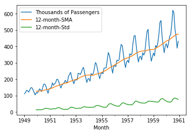

```python
df1['12-month-SMA'] = df1['Thousands of Passengers'].rolling(window=12).mean()
df1['12-month-Std'] = df1['Thousands of Passengers'].rolling(window=12).std()

df1[['Thousands of Passengers','12-month-SMA','12-month-Std']].plot();
```

Not only is this dataset seasonal with a clear upward trend, the standard deviation increases over time as well.

```python
print('Augmented Dickey-Fuller Test on Airline Data')
dftest = adfuller(df1['Thousands of Passengers'],autolag='AIC')
dftest
```

```
Augmented Dickey-Fuller Test on Airline Data
```

```
(0.8153688792060423,
 0.9918802434376409,
 13,
 130,
 {'1%': -3.4816817173418295,
  '5%': -2.8840418343195267,
  '10%': -2.578770059171598},
 996.6929308390189)
```

To find out what these values represent we can run `help(adfuller)`. Then we can add our own labels:

```python
print('Augmented Dickey-Fuller Test on Airline Data')

dfout = pd.Series(dftest[0:4],index=['ADF test statistic','p-value','# lags used','# observations'])

for key,val in dftest[4].items():
    dfout[f'critical value ({key})']=val
print(dfout)
```

```
Augmented Dickey-Fuller Test on Airline Data
ADF test statistic        0.815369
p-value                   0.991880
# lags used              13.000000
# observations          130.000000
critical value (1%)      -3.481682
critical value (5%)      -2.884042
critical value (10%)     -2.578770
dtype: float64
```

Here we have a very high p-value at 0.99, which provides weak evidence against the null hypothesis, and so we *fail to reject* the null hypothesis, and decide that our dataset is not stationary.  
Note: in statistics we don't "accept" a null hypothesis - nothing is ever truly proven - we just fail to reject it.  
Now let's apply the ADF test to stationary data with the Daily Total Female Births dataset.

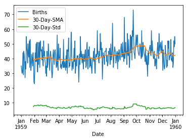

```python
df2['30-Day-SMA'] = df2['Births'].rolling(window=30).mean()
df2['30-Day-Std'] = df2['Births'].rolling(window=30).std()

df2[['Births','30-Day-SMA','30-Day-Std']].plot();
```

```python
print('Augmented Dickey-Fuller Test on Daily Female Births')
dftest = adfuller(df2['Births'],autolag='AIC')
dfout = pd.Series(dftest[0:4],index=['ADF test statistic','p-value','# lags used','# observations'])

for key,val in dftest[4].items():
    dfout[f'critical value ({key})']=val
print(dfout)
```

```
Augmented Dickey-Fuller Test on Daily Female Births
ADF test statistic       -4.808291
p-value                   0.000052
# lags used               6.000000
# observations          358.000000
critical value (1%)      -3.448749
critical value (5%)      -2.869647
critical value (10%)     -2.571089
dtype: float64
```

In this case our p-value is very low at 0.000052, and we do reject the null hypothesis. This dataset appears to have no unit root, and is stationary.

### Function for running the augmented Dickey-Fuller test

Since we'll use it frequently in the upcoming forecasts, let's define a function we can copy into future notebooks for running the augmented Dickey-Fuller test. Remember that we'll still have to import `adfuller` at the top of our notebook.

```python
from statsmodels.tsa.stattools import adfuller

def adf_test(series,title=''):
    """
    Pass in a time series and an optional title, returns an ADF report
    """
    print(f'Augmented Dickey-Fuller Test: {title}')
    result = adfuller(series.dropna(),autolag='AIC') # .dropna() handles differenced data

    labels = ['ADF test statistic','p-value','# lags used','# observations']
    out = pd.Series(result[0:4],index=labels)

    for key,val in result[4].items():
        out[f'critical value ({key})']=val

    print(out.to_string())          # .to_string() removes the line "dtype: float64"

    if result[1] <= 0.05:
        print("Strong evidence against the null hypothesis")
        print("Reject the null hypothesis")
        print("Data has no unit root and is stationary")
    else:
        print("Weak evidence against the null hypothesis")
        print("Fail to reject the null hypothesis")
        print("Data has a unit root and is non-stationary")
```

# Evaluating forecast accuracy

Two calculations related to linear regression are [**mean squared error**](https://en.wikipedia.org/wiki/Mean_squared_error) (MSE) and [**root mean squared error**](https://en.wikipedia.org/wiki/Root-mean-square_deviation) (RMSE)

The formula for the mean squared error is  
$MSE = {\frac 1 L} \sum\limits_{l=1}^L (y_{T+l} - \hat y_{T+l})^2$  
where $T$ is the last observation period and $l$ is the lag point up to $L$ number of test observations.

The formula for the root mean squared error is  
$RMSE = \sqrt{MSE} = \sqrt{{\frac 1 L} \sum\limits_{l=1}^L (y_{T+l} - \hat y_{T+l})^2}$

The advantage of the RMSE is that it is expressed in the same units as the data.

A method similar to the RMSE is the [**mean absolute error**](https://en.wikipedia.org/wiki/Mean_absolute_error) (MAE) which is the mean of the magnitudes of the error, given as

$MAE = {\frac 1 L} \sum\limits_{l=1}^L \mid{y_{T+l}} - \hat y_{T+l}\mid$

A forecast method that minimizes the MAE will lead to forecasts of the median, while minimizing the RMSE will lead to forecasts of the mean.

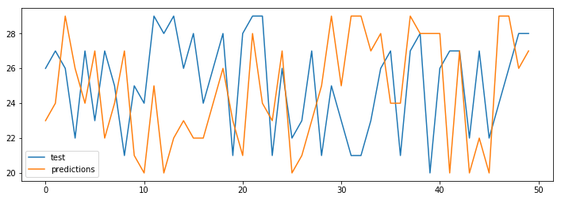

```python
import numpy as np
import pandas as pd
%matplotlib inline
np.random.seed(42)
df = pd.DataFrame(np.random.randint(20,30,(50,2)),columns=['test','predictions'])
df.plot(figsize=(12,4));
```

```python
MSE = mse(df['test'],df['predictions'])
RMSE = rmse(df['test'],df['predictions'])
MAE = meanabs(df['test'],df['predictions'])

print(f'Model  MSE: {MSE:.3f}')
print(f'Model RMSE: {RMSE:.3f}')
print(f'Model  MAE: {MAE:.3f}')
```

```
Model  MSE: 17.020
Model RMSE: 4.126
Model  MAE: 3.540
```

### AIC / BIC

More sophisticated tests include the [**Akaike information criterion**](https://en.wikipedia.org/wiki/Akaike_information_criterion) (AIC) and the [**Bayesian information criterion**](https://en.wikipedia.org/wiki/Bayesian_information_criterion) (BIC).

The AIC evaluates a collection of models and estimates the quality of each model relative to the others. Penalties are provided for the number of parameters used in an effort to thwart overfitting. The lower the AIC and BIC, the better the model should be at forecasting.

These functions are available as

`from from statsmodels.tools.eval_measures import aic, bic`

but we seldom compute them alone as they are built into many of the statsmodels tools we use.

## Exposing Seasonality with Month and Quarter Plots

Statsmodels has two plotting functions that group data by month and by quarter. Note that if the data appears as months, you should employ *resampling* with an aggregate function before running a quarter plot. These plots return a `matplotlib.Figure` object.

### Related Plot Methods:

```
tsaplots.month_plot(x)    Seasonal plot of monthly data


tsaplots.quarter_plot(x)  Seasonal plot of quarterly data
```

```python
import pandas as pd
import numpy as np
%matplotlib inline

df = pd.read_csv('../Data/airline_passengers.csv',index_col='Month',parse_dates=True)
df.index.freq = 'MS'
df.head()
```

| Month | Thousands of Passengers |
| --- | --- |
| 1949-01-01 | 112 |
| 1949-02-01 | 118 |
| 1949-03-01 | 132 |
| 1949-04-01 | 129 |
| 1949-05-01 | 121 |

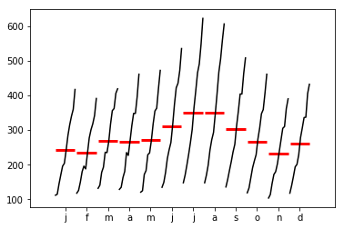

```python
from statsmodels.graphics.tsaplots import month_plot,quarter_plot

# Note: add a semicolon to prevent two plots being displayed in jupyter
month_plot(df['Thousands of Passengers']);
```

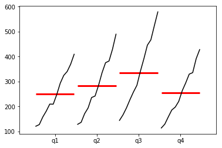

```python
dfq = df['Thousands of Passengers'].resample(rule='Q').mean()

quarter_plot(dfq);
```

Let's compare this to our nonseasonal `macrodata.csv` dataset:

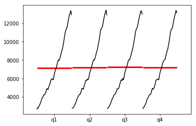

```python
df3 = pd.read_csv('../Data/macrodata.csv',index_col=0,parse_dates=True)
quarter_plot(df3['realgdp']);
```

### Great job!

Next up, we'll show how to determine the appropriate (p,d,q) orders for an ARIMA model.